# Exploration for Data Filtering HPE

Anna Steel

August 10, 2016

### Read in Data

- Open script from Fremont16.Rproj in GitHub to ensure directories are correct

```
## [1] "Prior to filtering, 130665 total positions in dataset"
```

```
## [1] "Prior to filtering, 438 inidividual fish positioned"
```

### Initial Data Cleaning

- remove exessively high HPEs (<1000) for ease later
- reduce dataset to only postions recorded after full VPS array was in place (don’t yet have removal dates, so not incorporated here)
- Create points in a spatial dataframe as well (both lat-long WGS84 & UTM)
- other steps to include here? – perhaps the tags with ID > 65000 are not fish tags for our study; the VEMCO report only considered those with tagIDs in the 36xxx, 38xxx, and 39xxx series; when we remove the 5 tags in the 65xxx series our initial values for n fish tags and n positions match those in the vemco report

```
## [1] "Removing 0 positions with HPEs > 1000"
```

```
## [1] "0 positions removed due to incomplete VPS array"
```

### Explore HPEs relationship with measured error for sync and reference tags

- Only positions with Hpes<1000
- Uses XY coordinates from VEMCO (Azimuthal Equal Area Projection)

```
## [1] 2.68366822228912
```

```
## [1] "At threshold of HPEs<1, mean measured error (m) of sync/ref positions = 3.7"
```

```
## [1] "At threshold of HPEs<1, median measured error (m) of sync/ref positions = 2.44"
```

```
## [1] "At threshold of HPEs<1, 90%ile of measured error (m) of sync/ref positions = 7.78"
```

```
## [1] "At threshold of HPEs<1, 83.72% of sync/ref positions retained"
```

### Spatial distribution of HPEs in fish positions (Similiar to Fig 9 in 2015 report)

- Eventually will add river line to these plots but needs more research to do in ggplot

# code pulled from 2015 to plot density contours of removed positions (based on HPE>0.5)

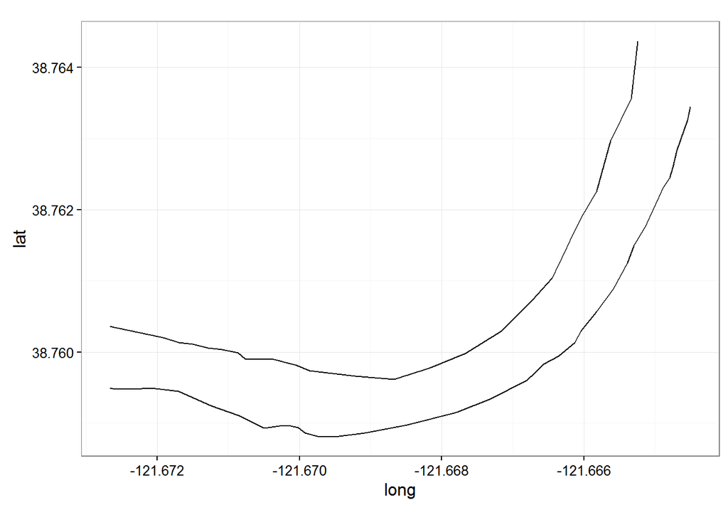

```r
   ggplot(ggriverbank) +  aes(long,lat,group=group, fill = id) +
          geom_path(color="black") +
          coord_equal() + theme_bw()
```

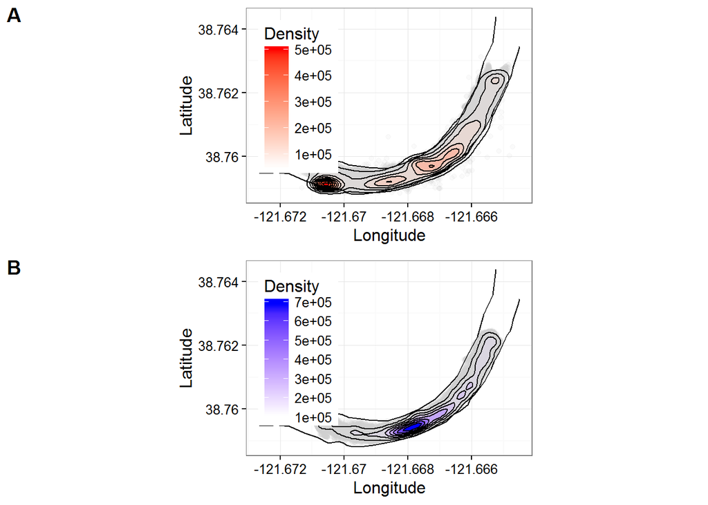

```r
    # create the constant theme and plots
    roundfunc <- function(l) { (l <- round(l, 3))}
     commonTheme = list(labs(color="Density",fill="Density",
                x="Longitude", y="Latitude"),
           theme_bw(),
           theme(legend.position=c(0,1),
                 legend.justification=c(0,1)))


      ptdens.keep =  ggplot(data=alldf[alldf$Hpes<0.5,],
                              aes(x=Longitude,y=Latitude)) +
            geom_point(alpha=.1, color="grey80") +
            stat_density2d(aes(fill=..level..,alpha=..level..),
                           geom='polygon',colour='black') +
            scale_fill_continuous(low="white",high="blue") +
            guides(alpha="none") + coord_fixed(ratio=1) +
            geom_path(data = ggriverbank, aes(long, lat, group=group)) +
            scale_y_continuous(label=roundfunc) +
            scale_x_continuous(label=roundfunc) +
            commonTheme

        ptdens.remove =  ggplot(data=alldf[alldf$Hpes>=0.5 & alldf$Hpes<500,],
                                aes(Longitude,Latitude)) +
            geom_point(alpha=.1, color="grey80") +
            stat_density2d(aes(fill=..level..,alpha=..level..),
                           geom='polygon',colour='black') +
            scale_fill_continuous(low="white",high="red") +
            guides(alpha="none") + coord_fixed(ratio=1) +
            geom_path(data = ggriverbank, aes(long, lat, group=group)) +
          scale_y_continuous(label=roundfunc,
                             limits=range(ggriverbank$lat)) +
            scale_x_continuous(label=roundfunc,
                               limits=range(ggriverbank$long)) +
            commonTheme

        # print plots in propwer grid
        windows()
        plot_grid(ptdens.remove, ptdens.keep, labels = c("A", "B"), ncol=1, align="v")
```

### Implement HPEs threshold in filtering

```
## [1] "After filtering @ HPEs<1, dataset retained:"
```

```
## [1] "  106529 positions,"
```

```
## [1] "  86.63% of fish tag positions"
```

```
## [1] "  433 individual fish"
```

Here is an excerpt from VEMCO’s results document that is returned with the post-processed VPS dataset, regarding thier estimate of the precision of the fish positions:

> Fish tag precision is estimated here using a simple method of comparing pairs of calculated positions that are very close in time, based on the knowledge that over a short period of time a fish will travel a relatively short distance. The time durations between successive transmissions of a fish tag in this study follow a pseudorandom sequence, with a minimum of 1.0 seconds, a maximum of 2.0 seconds, and an average of 1.5 seconds. For each of the HPEs filters, the retained positions are analyzed as follows: • Pairs of positions from the same transmitter that are within 2.0 seconds of each other are identified, and the horizontal distances between these pairs of positions are calculated • Selected percentiles of these horizontal distances are calculated The following is a summary of these analyses: HPEs # Pos % pos 50%ile 80%ile 90%ile 95%ile 0.2 25792 21% 1.34 2.04 2.56 3.16 0.5 83658 68% 1.57 2.54 3.45 4.62 1.0 106529 87% 1.68 2.93 4.21 5.86 For example, using an HPEs filter of 1.0, half of the pairs of calculated positions that are within 2.0 seconds of each other are less than 1.68 metres apart, and 80% are within 2.93m. Note that these statistics cannot be compared directly with the corresponding statistics for sync and reference tags because they include a component based on an average of 1.5 seconds of fish motion.

### Histograms of individual detections/GoodBasic positions for each calculated fish location:

- not of much interest but code was already written

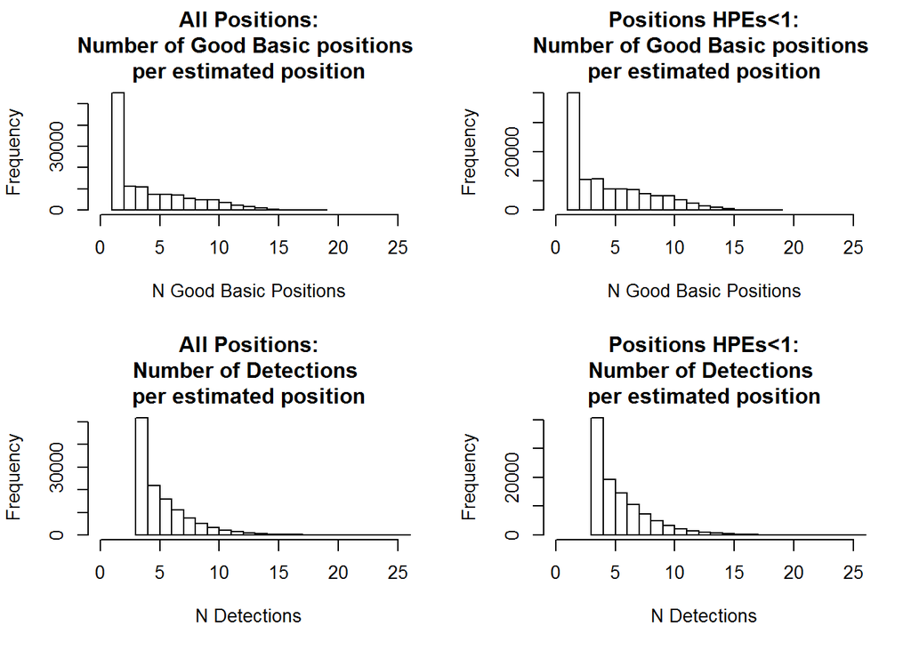

### Positions remaining per fish (Figs 8 and 10 in 2015 report)

```
##           Min.        1st Qu.         Median           Mean        3rd Qu.
##   37.000000000  185.000000000  238.000000000  283.986143187  317.000000000
##           Max.
## 5577.000000000
```

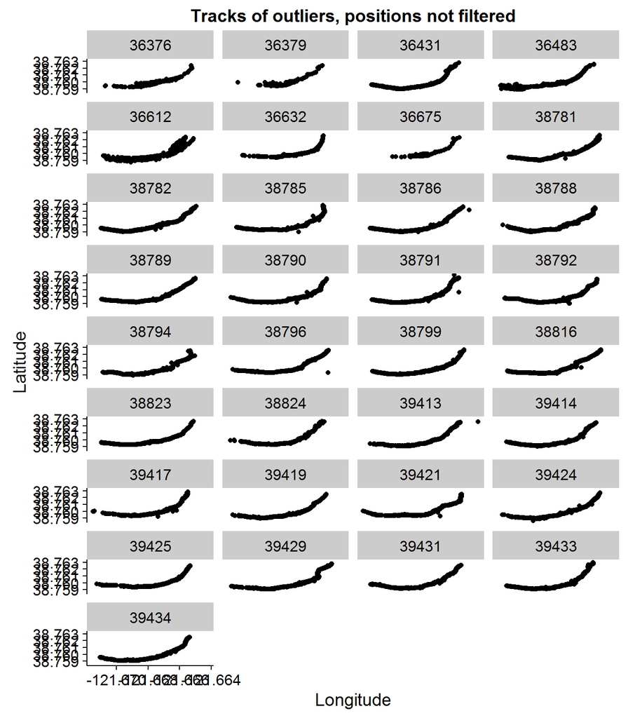

```
##           Min.        1st Qu.         Median           Mean        3rd Qu.
##   28.000000000  165.000000000  212.000000000  246.025404157  283.000000000
##           Max.
## 2015.000000000
```

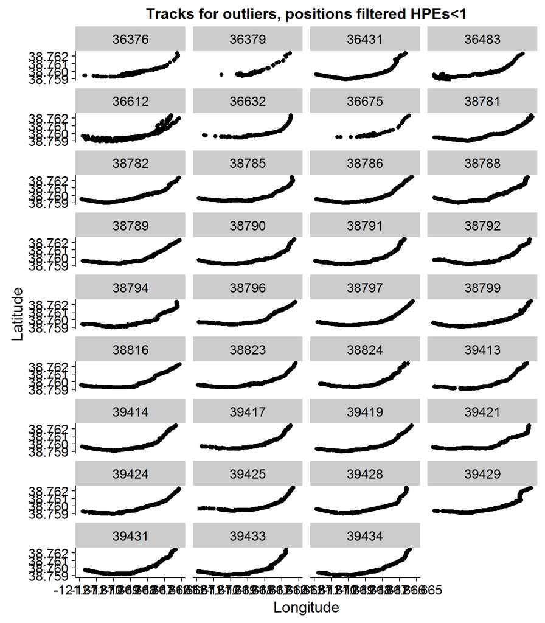

### Look at fish which >40% positions removed

- how many are there?
- are the tracks indicative of predator behavior?
- where are the errors?

```
## [1] "Only 1 fish with >40% of positions removed"
```

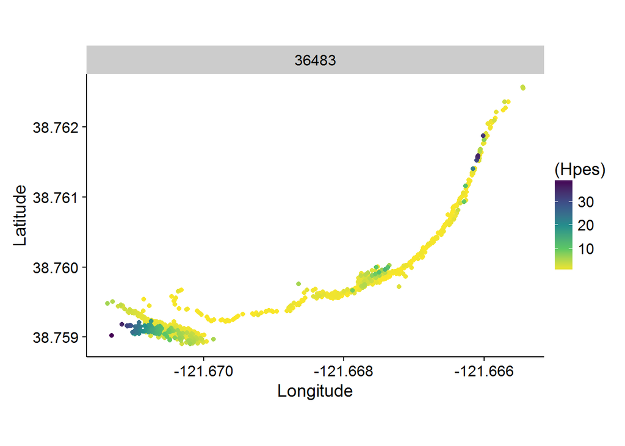

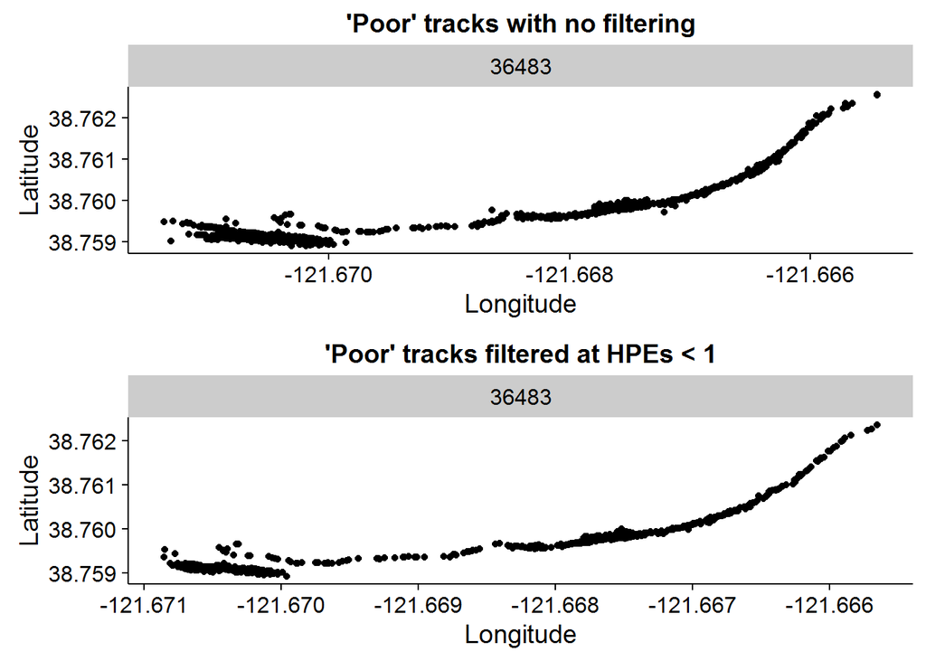